# Central Limit Theorem

Class 2

R Workshop

2019-02-18

지난 시간에는 ’정규분포에서 표집하기’와 ’심슨의 패러독스 시각화’를 통해 R의 기본적인 사용법을 살펴보았습니다. 이번 시간도 계속해서 R의 사용법에 익숙해지는 연습을 하겠습니다. 이번 시간의 주제는 학부통계에서 배우는, 가장 기본적인 개념 중 하나인 ’중심극한정리’입니다.  
먼저 모집단(population)과 표본(sample)의 관계에 대해 생각해봅시다. 우리가 표집(sampling)을 하는 이유는 모집단 전체를 연구할 수 없기 때문입니다. 대신 우리는 표집에 많은 정성을 기울입니다. 무선 표집의 중요성은 아무리 강조해도 지나치지 않지요. 그런데 표본을 통해 모집단에 대해 무엇을 알 수 있는 걸까요? 연구마다 관찰 대상이 다르고 주제가 다른데, 어떻게 일정한 통계 방법이 존재할 수 있을까요?

## 1. Sampling from normal distribution

### Defining population

정규분포 모집단을 만들려면 `rnorm` 함수를 사용하면 됩니다. 이 함수는 ‘R 소개’ 시간에 사용해본 적이 있습니다. $\mu = 0$, $\sigma = 1$인 정규분포에서 백 개의 값을 추출하여 히스토그램을 그렸지요. 이번에는 십만 개의 표본을 추출하여 히스토그램을 그려보겠습니다. 여기에서 ’십만 개’라는 숫자 자체는 큰 의미가 없습니다. 만 개 정도여도 괜찮고, 컴퓨팅 파워가 충분하다면 백만, 천만 개도 좋습니다. 표집을 할 수 밖에 없을 정도로 충분히 큰 수이면 됩니다.

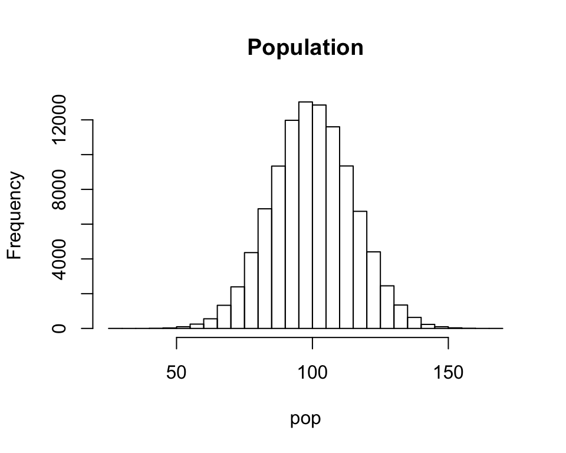

```r
pop <- rnorm(n=1e5, mean=100, sd=15)
hist(pop, breaks=50, main="Population")
```

1e5는 1 다음에 0이 다섯 개, 즉 100,000과 같습니다. 이제 pop 안에 십만 개의 값을 저장하였습니다. 이 값은 대학생들의 지능지수이거나, 정상인과 환자의 회상기억 점수 차이일 수도 있고, 참가자가 주의를 집중했을 때 두정엽 뉴런의 발화 빈도가 증가한 정도일 수도 있습니다. 모집단의 평균과 표준편차를 확인해봅시다.

```r
summary(pop)
```

```
##    Min. 1st Qu.  Median    Mean 3rd Qu.    Max.
##   28.59   89.89   99.90  100.00  110.13  168.99
```

```r
( mn.pop <- mean(pop) )
```

```
## [1] 100.0023
```

```r
( sd.pop <- sd(pop) )
```

```
## [1] 15.00582
```

평균 $\mu$와 표준편차 $\sigma$가 각각 100과 15에 가깝습니다. 모집단의 값들을 무작위로 생성하였으므로 약간의 오차는 있을 수 밖에 없습니다.

### Running a single study with N = 10

이제 모집단에서 10개의 값을 무선 표집합니다. `sample` 함수를 사용하겠습니다. 표본을 변수 samples에 넣고, 평균과 표준편차를 계산하여 모집단의 평균 및 표준편차와 비교해보세요.

```r
( samples = sample(pop, size=10) )
```

```
##  [1]  80.62805 110.71109 108.48341  97.09779  84.06810  77.29213 101.80721
##  [8]  94.27316  79.29754 101.38074
```

```r
mean(samples)
```

```
## [1] 93.50392
```

```r
sd(samples)
```

```
## [1] 12.40266
```

### Repeating the same study a lot of times

방금 했던 실험을 엄청나게 많이 반복해봅시다. 현실에서는 연구자가 똑같은 실험을 자꾸 반복하는 것이 여러가지 여건 상 쉽지 않을 뿐만 아니라 바람직하지도 않습니다. 우리는 위의 코드를 일만 번 반복하려 합니다. 이를 위해 For-loop를 사용하겠습니다.

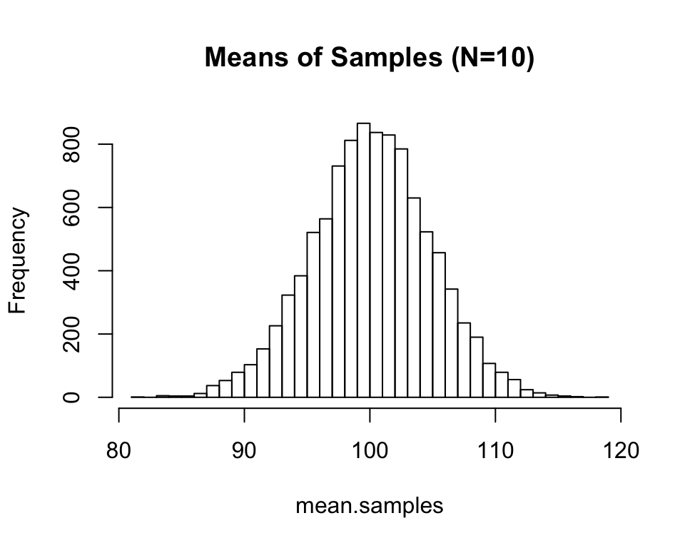

```r
mean.samples <- double()
for (it in 1:1e4){
  mean.samples[it] <- mean(sample(pop, size=10))
}
hist(mean.samples, breaks=50, main="Means of Samples (N=10)")
```

```r
( mn.mn.samples10 <- mean(mean.samples) )
```

```
## [1] 100.1186
```

```r
( sd.mn.samples10 <- sd(mean.samples) )
```

```
## [1] 4.739877
```

위 코드를 분석해봅시다. 먼저 mean.samples는 크기가 10인 표본의 평균을 저장할 변수입니다. 만 번 실험을 반복할 예정이므로 결국 만 개의 값을 가지게 될 겁니다. 일단 내용물 없이 이름만 만들었습니다. 이제 For-loop를 시작합니다. `{`와 `}` 사이에 있는 코드가 만 번 반복됩니다. 한 번째 코드가 실행될 때마다 it가 1씩 증가하고, 크기 10인 표본의 평균이 mean.samples의 it번째 공간에 하나씩 채워집니다. 만 번 반복이 된 후에는 히스토그램을 그리고 평균과 표준편차를 계산하였습니다.

**N=10인 표본의 평균들이 이루는 분포**의 평균과 표준편차를 모집단의 평균과 표준편차와 비교해보세요. 평균은 어떻습니까? 표준편차는 어떻습니까?

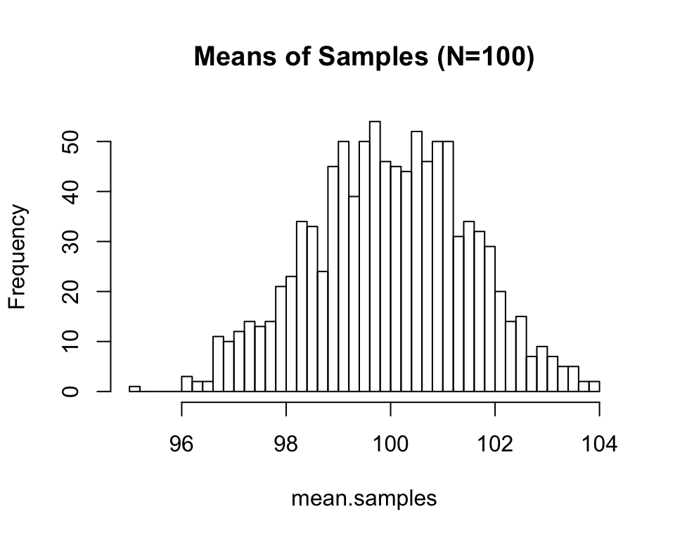

```r
mean.samples <- rep(NA, 1000)
for (it in 1:1e3){
  mean.samples[it] <- mean(sample(pop, size=100))
}
hist(mean.samples, breaks=50, main="Means of Samples (N=100)")
```

```r
( mn.mn.samples100 <- mean(mean.samples) )
```

```
## [1] 99.97811
```

```r
( sd.mn.samples100 <- sd(mean.samples) )
```

```
## [1] 1.518888
```

**N=100인 표본들 평균들이 이루는 분포**의 평균과 표준편차를 모집단의 평균과 표준편차와 비교해보세요. 평균은 어떻습니까? 표준편차는 어떻습니까?

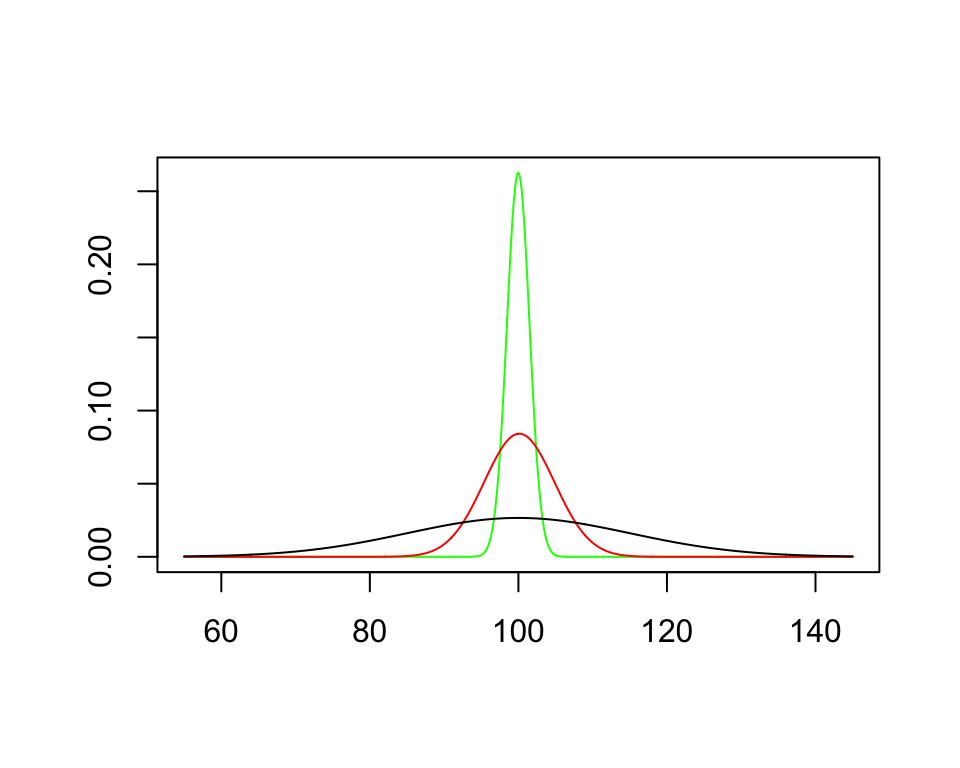

```r
x <- seq(from=55, to=145, length.out=1000)

y.samples100 <- dnorm(x, mean=mn.mn.samples100, sd=sd.mn.samples100)
plot(x, y.samples100, type='l', col='green', ann=FALSE)

y.samples10 <- dnorm(x, mean=mn.mn.samples10, sd=sd.mn.samples10)
lines(x, y.samples10, col='red')

y.pop <- dnorm(x, mean=mn.pop, sd=sd.pop)
lines(x, y.pop)
```

각 정규분포곡선은 아래의 면적(area under the curve, AUC)이 1이 되도록 표준화(standardized)되었습니다. 어떤 패턴이 보입니까? 왜 이런 패턴이 나올까요? N=100,000인 표본 평균들의 분포는 어떤 모습일까요?

다시 맨 처음의 첫 번째 질문으로 되돌아갑니다. 표본을 통해 모집단에 대해 무엇을 알 수 있을까요? 표본과 모집단은 어떤 관계를 가지고 있을까요? 아래는 모집단의 표준편차 $\sigma$를 표본 크기의 제곱근으로 각각 나누고 있습니다. 결과값을 sd.mn.samples10와 sd.mn.samples100에 비교해봅시다. 어떤가요?

```r
15/sqrt(10)
```

```
## [1] 4.743416
```

```r
15/sqrt(100)
```

```
## [1] 1.5
```

## 2. Sampling from non-normal distribution

이제 맨 처음에 했던 두 번째 질문에 대해 생각해봅시다. 지금까지 모집단이 정규분포를 가질 때 표본들의 평균이 어떤 모습을 가지는지 살펴보았습니다. 모집단의 분포가 정규분포가 아닌 경우는 어떨까요? 예를 들어, 모집단이 지수분포(exponential distribution)를 가질 때는 어떨까요?

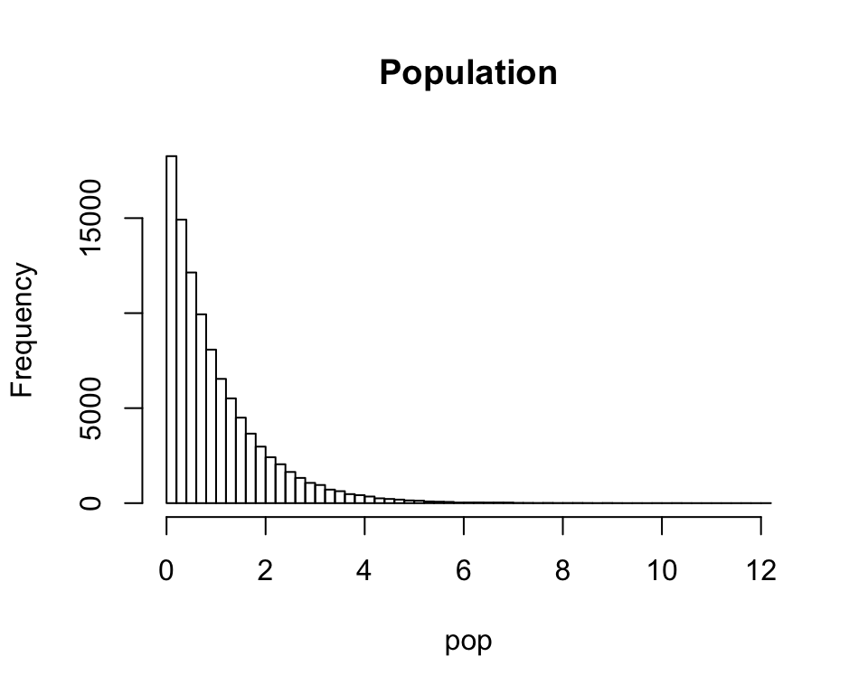

```r
rm(list=ls())
pop <- rexp(n=1e5)
hist(pop, breaks=50, main="Population")
```

```r
summary(pop)
```

```
##      Min.   1st Qu.    Median      Mean   3rd Qu.      Max.
##  0.000018  0.284393  0.687949  0.996854  1.384277 12.031537
```

```r
( mn.pop <- mean(pop) )
```

```
## [1] 0.9968536
```

```r
( sd.pop <- sd(pop) )
```

```
## [1] 0.9976169
```

지수분포는 대칭적인 분포가 아닐 뿐만 아니라 0보다 큰 값들만 가지고 있습니다. 이런 모집단에서 반복적으로 표본을 추출하여 평균의 분포를 그려보면, 어떤 모습이 나타날까요?

지수분포 모집단에서 크기 10인 표본을 만 개 선택하여 평균의 분포를 그려보세요. 이 분포의 평균과 표준편차를 모집단과 비교해보세요. 이제 두 번째 질문에 대한 답을 말해보세요.

이번 시간에는 모수 통계(parametric statistics)의 중요한 근거가 되는 중심극한정리에 대해 공부하였습니다. 다음 시간에는 좀 더 구체적인 모수 통계 방법을 공부하겠습니다.